# Fragrance Classification Project

The purpose of the project is to accurately classify the fragrances 1, 2, 3 & 4 based on the data logged on 12 different human subjects on the brainwave activities in the alpha, delta and theta wave spectrum. 20 channels of 5 explanatory variables - alpha wave, delta wave, theta wave, sample entropy and Higuchi Fractal Dimension - are given for every row. The approach for the project shown in the notebook is to visualise the data, clean the data and, finally, model the data to determine highest accuracy score.

Data is visualised using matplotlib to identify their distribution and determine the best data cleaning techniques.

To clean the data, columns found to have logarithmic distributions are logged (using natural logarithm) and scaled using MinMaxScaler from Scikit-Learn. Dimension reduction techniques are also applied to engineer variables that contains information from all the columns.

Lastly, five machine learning modelling techniques are used after each data cleaning method:

- Logistic Regression,
- K-Nearest Neighbour Classifier,
- Support Vector Machine,
- Random Forest Classifier and,
- Decision Tree Classifier

to classify the fragrances. An accuracy score is then calculated based on whether the model predicted the test dataset correctly and a confusion matrix is shown to see the accuracy across the 4 fragrances. An average accuracy score is calculated too using StratifiedKFold cross validation technique that randomly splits training and test data to 5-fold splits.

Authors:

- Chan Tiong Ley
- Le Khang Tai
- Moh Chin Wei

Colab Link: https://colab.research.google.com/drive/1wNmc8Dsxv-n9Xq0LjENgY46FFZZqbiNe

## Importing data

```python
import pandas as pd
import numpy as np
df = pd.read_csv('database_adt.csv')
df.head()
```

|  | subject | fragance | ch1Delta | ch1Theta | ch1Alpha | ch1HFD | ch1SampEn | ch2Delta | ch2Theta | ch2Alpha | ... | ch19Delta | ch19Theta | ch19Alpha | ch19HFD | ch19SampEn | ch20Delta | ch20Theta | ch20Alpha | ch20HFD | ch20SampEn |
| --- | --- | --- | --- | --- | --- | --- | --- | --- | --- | --- | --- | --- | --- | --- | --- | --- | --- | --- | --- | --- | --- |
| 0 | 1 | 1 | 35.921507 | 4.412490 | 1.756444 | 1.014790 | 0.088427 | 36.164668 | 10.895261 | 2.055819 | ... | 18.434658 | 4.967467 | 1.141831 | 1.009489 | 0.107069 | 11.558199 | 4.655697 | 1.157401 | 1.009273 | 0.109482 |
| 1 | 1 | 1 | 13.830605 | 1.917780 | 1.546757 | 1.012598 | 0.102700 | 47.435486 | 6.661602 | 0.882648 | ... | 18.240004 | 3.105871 | 0.574149 | 1.010296 | 0.084849 | 12.022048 | 2.551235 | 0.843120 | 1.009959 | 0.074365 |
| 2 | 1 | 1 | 36.077117 | 5.034314 | 0.739862 | 1.007153 | 0.085620 | 37.266809 | 4.081424 | 1.185940 | ... | 11.404557 | 2.240443 | 0.452632 | 1.008621 | 0.089110 | 19.991842 | 3.909551 | 0.682052 | 1.008055 | 0.099436 |
| 3 | 1 | 1 | 198.426316 | 10.188028 | 2.372590 | 1.004590 | 0.059954 | 97.207527 | 14.338401 | 2.422131 | ... | 11.928661 | 5.114008 | 1.131790 | 1.006481 | 0.090805 | 35.063647 | 4.416584 | 1.094357 | 1.005598 | 0.075808 |
| 4 | 1 | 1 | 6.151901 | 1.675972 | 0.536591 | 1.014166 | 0.151997 | 5.573831 | 1.893517 | 0.582847 | ... | 10.268172 | 2.143268 | 0.738775 | 1.013914 | 0.150177 | 5.527356 | 1.704020 | 1.423688 | 1.016764 | 0.191937 |

5 rows × 102 columns

## Understanding the correlation between the Fragrance and other columns

```python
c = df.corr().abs()
c['fragance'].sort_values()
```

```
subject      3.411784e-18
ch17Theta    1.100649e-03
ch11Delta    2.212474e-03
ch15Delta    3.166998e-03
ch2HFD       3.383740e-03
                 ...
ch8SampEn    1.119629e-01
ch13HFD      1.120226e-01
ch6Alpha     1.129461e-01
ch10Delta    1.390017e-01
fragance     1.000000e+00
Name: fragance, Length: 102, dtype: float64
```

```python
c = df.corr().abs().unstack()
c = c[c < 1].sort_values()
c = c[c>0.8].drop_duplicates()
c
```

```
ch3Theta   ch3Delta      0.807564
ch4SampEn  ch19SampEn    0.811953
ch19Theta  ch18Alpha     0.814602
ch9Theta   ch9Delta      0.815739
ch12Alpha  ch8Alpha      0.818433
ch4Theta   ch4Delta      0.821946
ch1Alpha   ch12Alpha     0.837102
ch2Theta   ch18Alpha     0.849090
ch19Delta  ch18Delta     0.851119
ch19Alpha  ch19Theta     0.865888
           ch18Alpha     0.875627
ch15Delta  ch8Delta      0.880022
ch19Alpha  ch18Theta     0.890868
           ch2Theta      0.891392
ch18Alpha  ch18Theta     0.896441
           ch2Alpha      0.901876
ch19Theta  ch2Alpha      0.913944
ch13Theta  ch13Delta     0.922681
ch6Theta   ch6Delta      0.927464
ch18Theta  ch2Alpha      0.930615
ch19Theta  ch18Theta     0.937577
ch2Theta   ch18Theta     0.945592
ch9Alpha   ch9Theta      0.951330
ch2Alpha   ch2Theta      0.955793
ch19Alpha  ch2Alpha      0.956683
ch19Delta  ch2Delta      0.972249
ch2Theta   ch19Theta     0.973661
dtype: float64
```

Conclusion: While it seems that no column has any direct relationship with the "fragrance" variable, many of the brain waves are highly correlated.

# Data Visualisation

## Delta brainwaves for some subject-patient pairing

```python
import matplotlib.pyplot as plt

def getColumns(waveType):
    columnList = []
    for channel_number in range(1, 21):
        columnList.append('ch{}{}'.format(channel_number, waveType))
    return columnList
```

```
Data for Subject 1.0, Fragrance 1.0
```

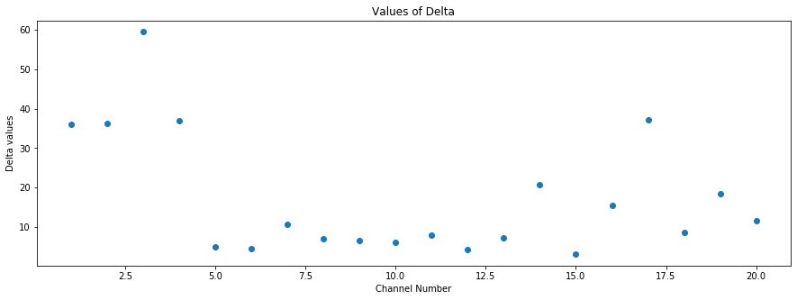

```
Data for Subject 8.0, Fragrance 1.0
```

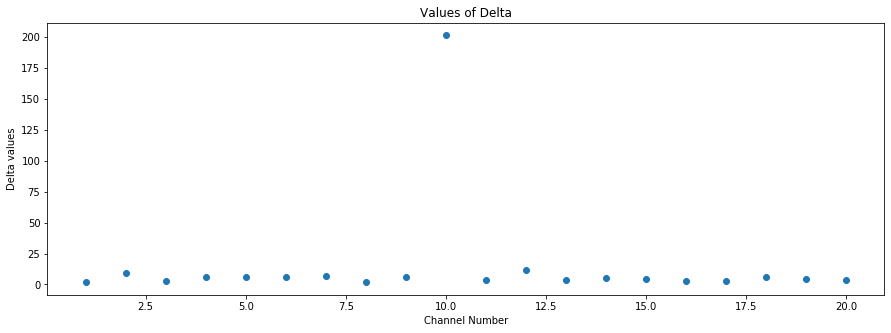

```
Data for Subject 3.0, Fragrance 2.0
```

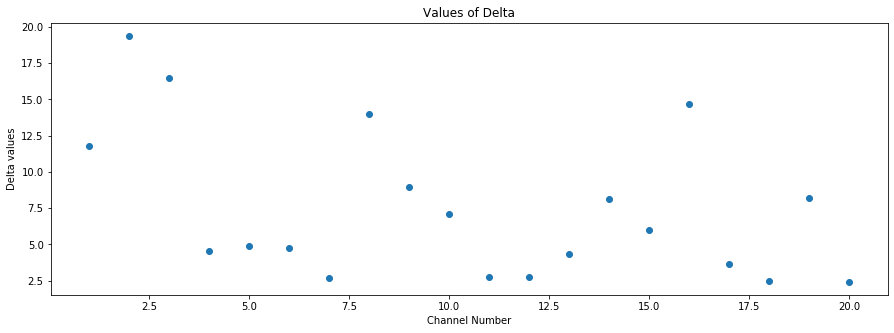

```
Data for Subject 11.0, Fragrance 2.0
```

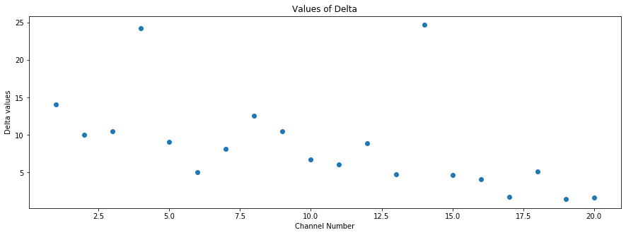

```
Data for Subject 6.0, Fragrance 3.0
```

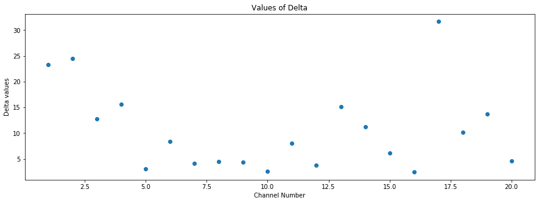

```
Data for Subject 1.0, Fragrance 4.0
```

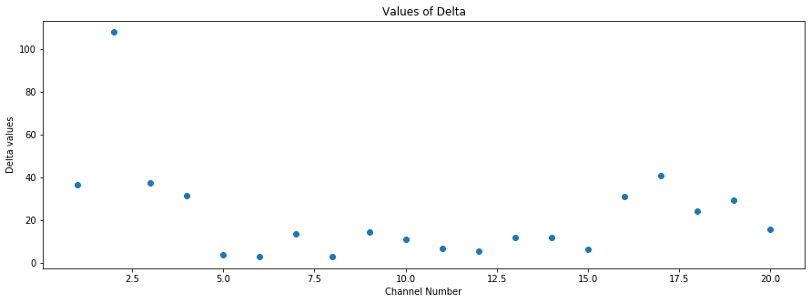

```
Data for Subject 9.0, Fragrance 4.0
```

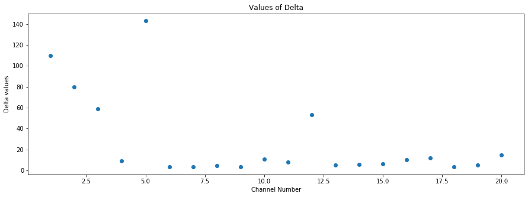

```python
waveType = 'Delta'

for idx in range(0, df.shape[0], 40):
    df01 = df[df.index == idx]
    subject = df01.iloc[0]['subject']
    fragrance = df01.iloc[0]['fragance']

    print('Data for Subject {}, Fragrance {}'.format(subject, fragrance))

    columns = getColumns(waveType)
    df02 = df01[columns]
    vals = df02.values.tolist()[0][0:]

    plt.figure(figsize=(15,5))
    plt.title('Values of {}'.format(waveType))
    plt.xlabel('Channel Number')
    plt.ylabel('{} values'.format(waveType))
    plt.scatter(np.arange(1,21), vals)
    plt.show()
```

## Theta brainwaves for some subject-patient pairing

```
Data for Subject 1.0, Fragrance 1.0
```

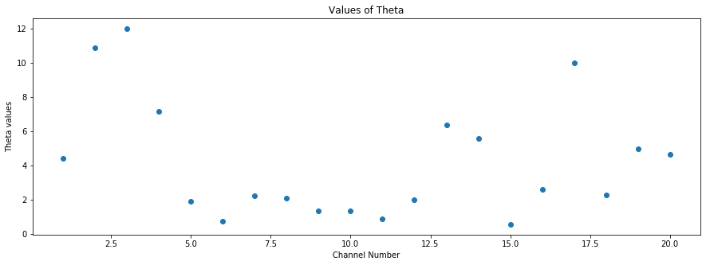

```
Data for Subject 8.0, Fragrance 1.0
```

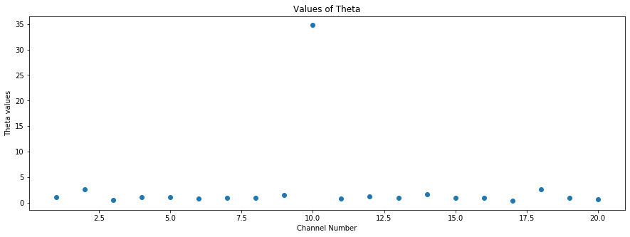

```
Data for Subject 3.0, Fragrance 2.0
```

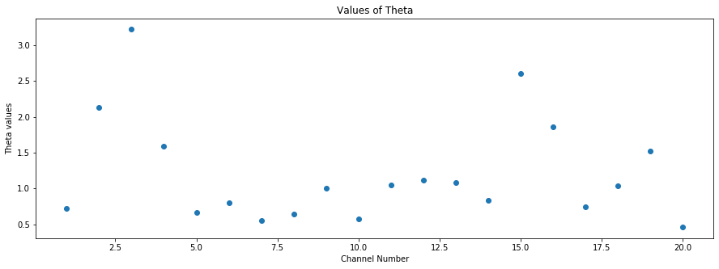

```
Data for Subject 11.0, Fragrance 2.0
```

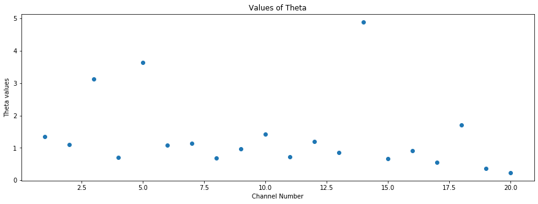

```
Data for Subject 6.0, Fragrance 3.0
```

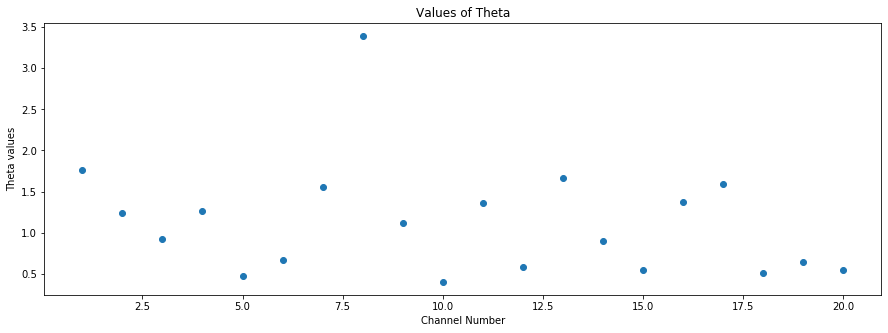

```
Data for Subject 1.0, Fragrance 4.0
```

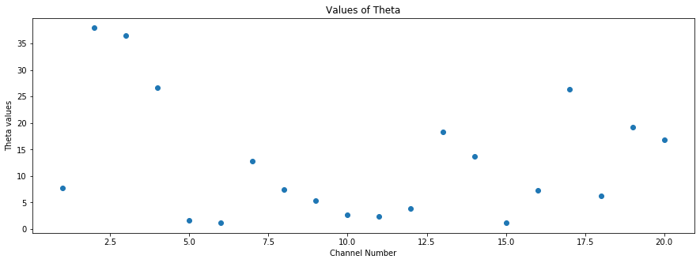

```
Data for Subject 9.0, Fragrance 4.0
```

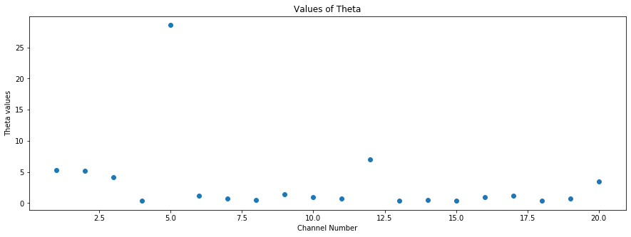

```python
waveType = 'Theta'

for idx in range(0, df.shape[0], 40):
    df01 = df[df.index == idx]
    subject = df01.iloc[0]['subject']
    fragrance = df01.iloc[0]['fragance']

    print('Data for Subject {}, Fragrance {}'.format(subject, fragrance))

    columns = getColumns(waveType)
    df02 = df01[columns]
    vals = df02.values.tolist()[0][0:]

    plt.figure(figsize=(15,5))
    plt.title('Values of {}'.format(waveType))
    plt.xlabel('Channel Number')
    plt.ylabel('{} values'.format(waveType))
    plt.scatter(np.arange(1,21), vals)
    plt.show()
```

```
Data for Subject 1.0, Fragrance 1.0
```

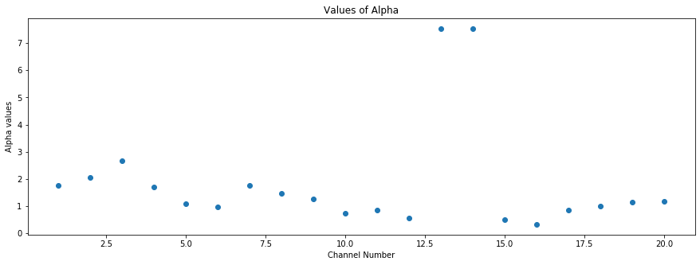

```
Data for Subject 8.0, Fragrance 1.0
```

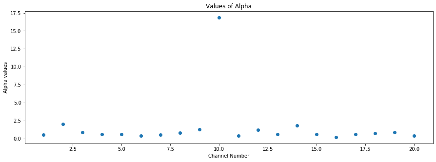

```
Data for Subject 3.0, Fragrance 2.0
```

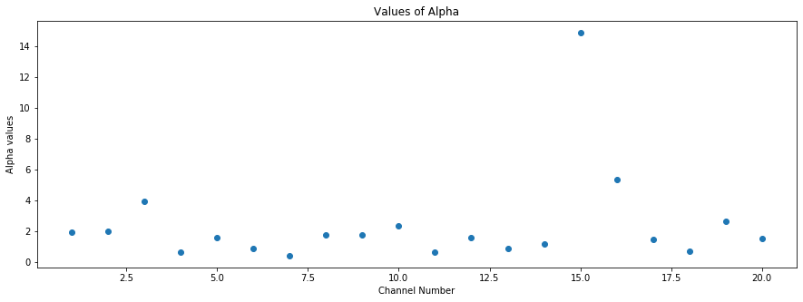

```
Data for Subject 11.0, Fragrance 2.0
```

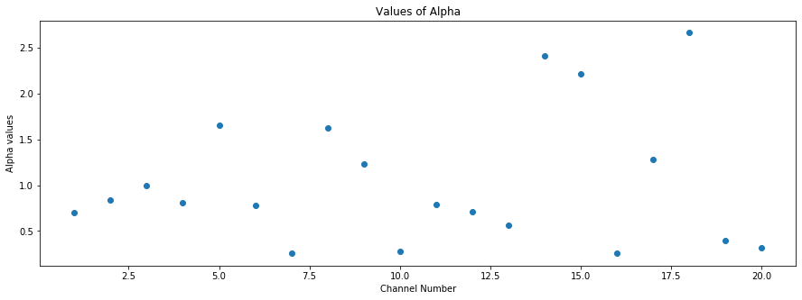

```
Data for Subject 6.0, Fragrance 3.0
```

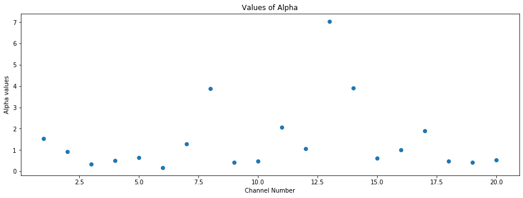

```
Data for Subject 1.0, Fragrance 4.0
```

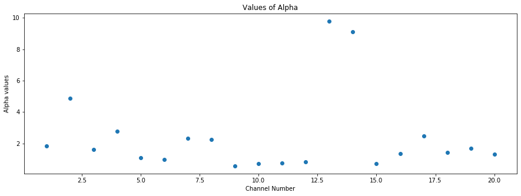

```
Data for Subject 9.0, Fragrance 4.0
```

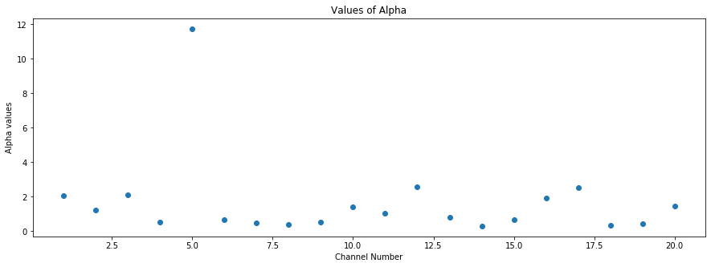

```python
waveType = 'Alpha'

for idx in range(0, df.shape[0], 40):
    df01 = df[df.index == idx]
    subject = df01.iloc[0]['subject']
    fragrance = df01.iloc[0]['fragance']

    print('Data for Subject {}, Fragrance {}'.format(subject, fragrance))

    columns = getColumns(waveType)
    df02 = df01[columns]
    vals = df02.values.tolist()[0][0:]

    plt.figure(figsize=(15,5))
    plt.title('Values of {}'.format(waveType))
    plt.xlabel('Channel Number')
    plt.ylabel('{} values'.format(waveType))
    plt.scatter(np.arange(1,21), vals)
    plt.show()
```

## Distribution for all the columns

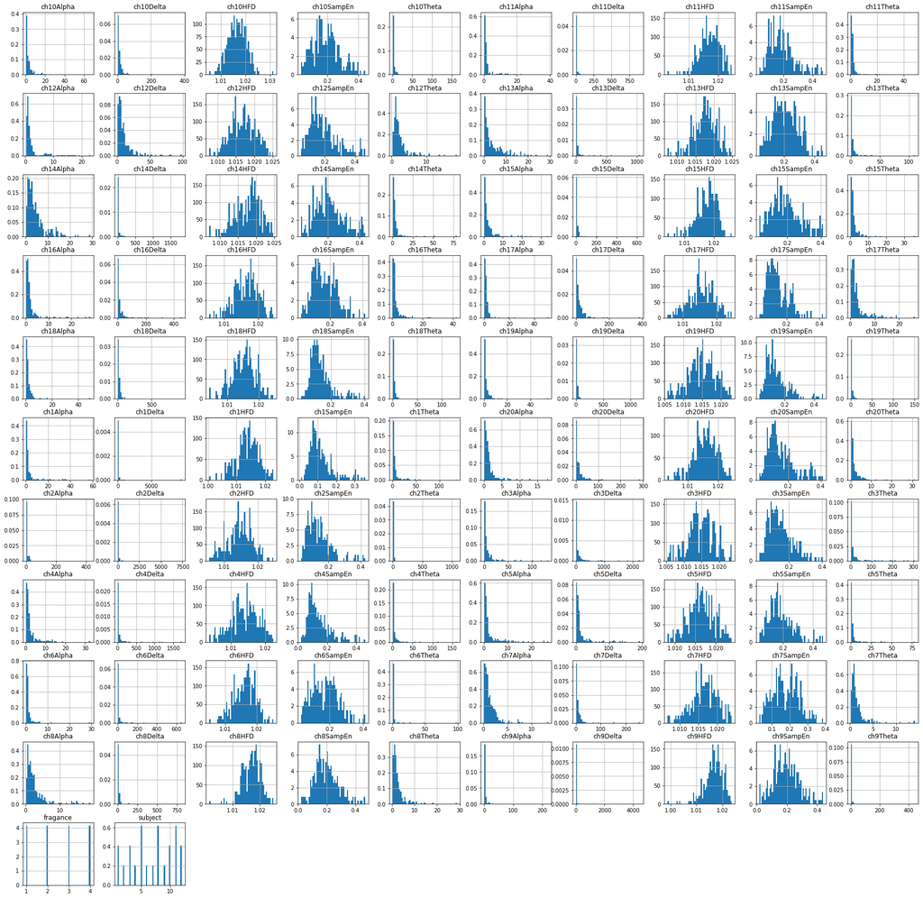

```python
df.hist(bins=50, density=True, figsize=(30,30))
plt.show()
```

# Modelling with raw data

## Try Linear Discriminant Analysis with all columns from raw data

Conclusion: Accuracy score up to 70%.

```python
from sklearn.model_selection import train_test_split
from sklearn.tree import DecisionTreeClassifier
from sklearn.ensemble import RandomForestClassifier
from sklearn.metrics import confusion_matrix, accuracy_score
from sklearn.svm import SVC
from sklearn.neighbors import KNeighborsClassifier
from sklearn.linear_model import LogisticRegression
```

```python
columns01 = df.columns[2:]
X = df[columns01]
y = df[['fragance']]
```

```
[0.50182184 0.30107765 0.19710052]
```

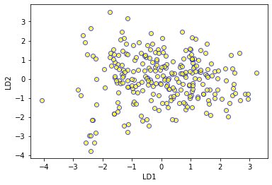

```python
from sklearn.discriminant_analysis import LinearDiscriminantAnalysis
import matplotlib.pyplot as plt

lda = LinearDiscriminantAnalysis()
X_lda = lda.fit_transform(X, y.values.ravel())
print(lda.explained_variance_ratio_)
plt.xlabel('LD1')
plt.ylabel('LD2')
plt.scatter(
    X_lda[:,0],
    X_lda[:,1],
    c='yellow',
    cmap='rainbow',
    alpha=0.7,
    edgecolors='b'
)
plt.show()
```

### Split to train and test dataset

```python
X_train, X_test, y_train, y_test = train_test_split(X_lda, y, random_state=42, test_size=0.4)
```

### Using Logistic Regression

```python
lm = LogisticRegression()
lm.fit(X_train, y_train.values.ravel())
y_pred = lm.predict(X_test)
print('Accuracy Score:', accuracy_score(y_test, y_pred))
print(confusion_matrix(y_test, y_pred))
```

```
Accuracy Score: 0.7075471698113207
[[14  3  3  1]
 [ 5 22  2  2]
 [ 4  4 20  2]
 [ 2  2  1 19]]
```

### Using KNN Classifier

```python
knn = KNeighborsClassifier()
knn.fit(X_train, y_train.values.ravel())
y_pred = knn.predict(X_test)
print('Accuracy Score:', accuracy_score(y_test, y_pred))
print(confusion_matrix(y_test, y_pred))
```

```
Accuracy Score: 0.5754716981132075
[[15  1  4  1]
 [11 15  2  3]
 [ 5  4 17  4]
 [ 2  4  4 14]]
```

### Using Support Vector Machines

```python
svc = SVC()
svc.fit(X_train, y_train.values.ravel())
y_pred = svc.predict(X_test)
print('Accuracy Score:', accuracy_score(y_test, y_pred))
print(confusion_matrix(y_test, y_pred))
```

```
Accuracy Score: 0.6981132075471698
[[16  1  3  1]
 [ 8 19  1  3]
 [ 3  4 19  4]
 [ 2  1  1 20]]
```

### Using Random Forest Classifier

```python
clf = RandomForestClassifier(random_state=1)
clf.fit(X_train, y_train.values.ravel())
y_pred = clf.predict(X_test)
print('Accuracy Score:', accuracy_score(y_test, y_pred))
print(confusion_matrix(y_test, y_pred))
```

```
Accuracy Score: 0.6981132075471698
[[16  1  3  1]
 [ 6 20  3  2]
 [ 4  3 19  4]
 [ 1  1  3 19]]
```

### Using Decision Tree Classifier

```python
ccp_alpha_list = [0, 0.0001,0.001,0.01,0.1]
criterion_list = ['gini', 'entropy']

highest_accuracy = 0
highest_ccp_alpha = 0
highest_criterion = ''

for ccp_alpha_val in ccp_alpha_list:
  for criterion_val in criterion_list:
      dt = DecisionTreeClassifier(criterion=criterion_val, ccp_alpha=ccp_alpha_val)
      dt.fit(X_train, y_train)
      y_pred = dt.predict(X_test)
      accuracy = accuracy_score(y_test, y_pred)
      if accuracy > highest_accuracy:
        highest_accuracy = accuracy
        highest_ccp_alpha = ccp_alpha_val
        highest_criterion = criterion_val
print(highest_ccp_alpha, highest_criterion)

dt = DecisionTreeClassifier(criterion=highest_criterion, ccp_alpha=highest_ccp_alpha)
dt.fit(X_train, y_train)
y_pred = dt.predict(X_test)
print('Accuracy score:', accuracy_score(y_test, y_pred))
print(confusion_matrix(y_test, y_pred))
```

```
0 gini
Accuracy score: 0.6320754716981132
[[15  1  4  1]
 [ 7 16  5  3]
 [ 3  5 18  4]
 [ 2  1  3 18]]
```

## Try Quadratic Discriminant Analysis

```python
from sklearn.discriminant_analysis import QuadraticDiscriminantAnalysis

X = df[columns01]
y = df['fragance']
```

### Split to train and test dataset

```python
  X_train, X_test, y_train, y_test = train_test_split(X, y, random_state=42, test_size=0.4)
```

### Perform Classifier with QDA

```python
qda = QuadraticDiscriminantAnalysis()
qda.fit(X_train, y_train.values.ravel())
y_pred = qda.predict(X_test)
print(accuracy_score(y_pred, y_test))
print(confusion_matrix(y_pred, y_test))
qda.get_params()
```

```
0.25471698113207547
[[ 5  7  6  7]
 [ 9 14 15 10]
 [ 3  7  5  4]
 [ 4  3  4  3]]
```

```
{'priors': None, 'reg_param': 0.0, 'store_covariance': False, 'tol': 0.0001}
```

## Try Principal Component Analysis

```python
from sklearn.preprocessing import MinMaxScaler

columns01 = df.columns[2:]
df01 = df.drop(['subject', 'fragance'], axis=1)
df02 = df[['subject', 'fragance']]

scaler = MinMaxScaler()
df01 = pd.DataFrame(scaler.fit_transform(df01))
df01.columns = columns01
df01 = pd.concat([df01, df02], axis=1)
df01
```

|  | ch1Delta | ch1Theta | ch1Alpha | ch1HFD | ch1SampEn | ch2Delta | ch2Theta | ch2Alpha | ch2HFD | ch2SampEn | ... | ch19Alpha | ch19HFD | ch19SampEn | ch20Delta | ch20Theta | ch20Alpha | ch20HFD | ch20SampEn | subject | fragance |
| --- | --- | --- | --- | --- | --- | --- | --- | --- | --- | --- | --- | --- | --- | --- | --- | --- | --- | --- | --- | --- | --- |
| 0 | 0.003625 | 0.030963 | 0.025854 | 0.638522 | 0.230404 | 0.004767 | 0.009893 | 0.004305 | 0.279138 | 0.200599 | ... | 0.019100 | 0.221562 | 0.182284 | 0.038924 | 0.146281 | 0.056881 | 0.285087 | 0.221361 | 1 | 1 |
| 1 | 0.001304 | 0.012715 | 0.022209 | 0.540931 | 0.271395 | 0.006289 | 0.005961 | 0.001560 | 0.285675 | 0.169345 | ... | 0.008881 | 0.268584 | 0.130817 | 0.040547 | 0.078959 | 0.039277 | 0.317583 | 0.131886 | 1 | 1 |
| 2 | 0.003642 | 0.035512 | 0.008182 | 0.298449 | 0.222344 | 0.004916 | 0.003565 | 0.002270 | 0.153364 | 0.163806 | ... | 0.006694 | 0.171040 | 0.140687 | 0.068435 | 0.122412 | 0.030255 | 0.227357 | 0.195765 | 1 | 1 |
| 3 | 0.020702 | 0.073210 | 0.036565 | 0.184369 | 0.148638 | 0.013012 | 0.013090 | 0.005163 | 0.084150 | 0.167686 | ... | 0.018920 | 0.046490 | 0.144612 | 0.121175 | 0.138632 | 0.053350 | 0.110880 | 0.135563 | 1 | 1 |
| 4 | 0.000497 | 0.010946 | 0.004648 | 0.610746 | 0.412962 | 0.000635 | 0.001533 | 0.000858 | 0.441621 | 0.301411 | ... | 0.011845 | 0.479204 | 0.282136 | 0.017820 | 0.051856 | 0.071797 | 0.640160 | 0.431447 | 1 | 1 |
| ... | ... | ... | ... | ... | ... | ... | ... | ... | ... | ... | ... | ... | ... | ... | ... | ... | ... | ... | ... | ... | ... |
| 259 | 0.014288 | 0.261740 | 0.176800 | 0.279177 | 0.417188 | 0.014422 | 0.019890 | 0.020804 | 0.130422 | 0.347013 | ... | 0.038924 | 0.689713 | 0.541370 | 0.005350 | 0.005780 | 0.073413 | 0.874618 | 0.891754 | 12 | 4 |
| 260 | 0.004649 | 0.258583 | 0.190308 | 0.349871 | 0.577123 | 0.003345 | 0.028795 | 0.024190 | 0.239570 | 0.418541 | ... | 0.060743 | 0.564380 | 0.580075 | 0.003789 | 0.035636 | 0.103309 | 0.711296 | 0.590036 | 12 | 4 |
| 261 | 0.008981 | 0.035830 | 0.576691 | 0.826291 | 1.000000 | 0.004746 | 0.003920 | 0.071055 | 0.772972 | 1.000000 | ... | 0.092405 | 0.909207 | 1.000000 | 0.009139 | 0.023288 | 0.086449 | 0.799132 | 0.950974 | 12 | 4 |
| 262 | 0.011061 | 0.103351 | 1.000000 | 0.723804 | 0.827066 | 0.010091 | 0.005407 | 0.125148 | 0.650526 | 0.717691 | ... | 0.228520 | 0.801668 | 0.465542 | 0.138163 | 0.075211 | 0.396804 | 0.731583 | 0.237223 | 12 | 4 |
| 263 | 0.008403 | 0.121016 | 0.602363 | 0.832498 | 0.826488 | 0.006166 | 0.012358 | 0.075311 | 0.740186 | 0.891325 | ... | 0.108577 | 0.776990 | 0.902701 | 0.008797 | 0.029734 | 0.139001 | 0.776253 | 0.808992 | 12 | 4 |

264 rows × 102 columns

```
[0.41958539 0.26803773]
```

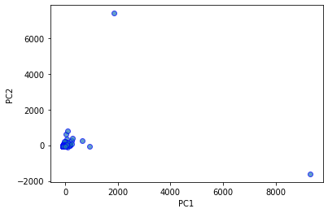

|  | ch1Delta | ch1Theta | ch1Alpha | ch1HFD | ch1SampEn | ch2Delta | ch2Theta | ch2Alpha | ch2HFD | ch2SampEn | ... | ch19Delta | ch19Theta | ch19Alpha | ch19HFD | ch19SampEn | ch20Delta | ch20Theta | ch20Alpha | ch20HFD | ch20SampEn |
| --- | --- | --- | --- | --- | --- | --- | --- | --- | --- | --- | --- | --- | --- | --- | --- | --- | --- | --- | --- | --- | --- |
| 0 | 35.921507 | 4.412490 | 1.756444 | 1.014790 | 0.088427 | 36.164668 | 10.895261 | 2.055819 | 1.010957 | 0.109852 | ... | 18.434658 | 4.967467 | 1.141831 | 1.009489 | 0.107069 | 11.558199 | 4.655697 | 1.157401 | 1.009273 | 0.109482 |
| 1 | 13.830605 | 1.917780 | 1.546757 | 1.012598 | 0.102700 | 47.435486 | 6.661602 | 0.882648 | 1.011081 | 0.097482 | ... | 18.240004 | 3.105871 | 0.574149 | 1.010296 | 0.084849 | 12.022048 | 2.551235 | 0.843120 | 1.009959 | 0.074365 |
| 2 | 36.077117 | 5.034314 | 0.739862 | 1.007153 | 0.085620 | 37.266809 | 4.081424 | 1.185940 | 1.008573 | 0.095289 | ... | 11.404557 | 2.240443 | 0.452632 | 1.008621 | 0.089110 | 19.991842 | 3.909551 | 0.682052 | 1.008055 | 0.099436 |
| 3 | 198.426316 | 10.188028 | 2.372590 | 1.004590 | 0.059954 | 97.207527 | 14.338401 | 2.422131 | 1.007262 | 0.096825 | ... | 11.928661 | 5.114008 | 1.131790 | 1.006481 | 0.090805 | 35.063647 | 4.416584 | 1.094357 | 1.005598 | 0.075808 |
| 4 | 6.151901 | 1.675972 | 0.536591 | 1.014166 | 0.151997 | 5.573831 | 1.893517 | 0.582847 | 1.014036 | 0.149755 | ... | 10.268172 | 2.143268 | 0.738775 | 1.013914 | 0.150177 | 5.527356 | 1.704020 | 1.423688 | 1.016764 | 0.191937 |
| ... | ... | ... | ... | ... | ... | ... | ... | ... | ... | ... | ... | ... | ... | ... | ... | ... | ... | ... | ... | ... | ... |
| 259 | 137.394395 | 35.961829 | 10.439399 | 1.006720 | 0.153468 | 107.649326 | 21.659997 | 9.105356 | 1.008139 | 0.167805 | ... | 7.758770 | 1.256975 | 2.243037 | 1.017530 | 0.262095 | 1.963812 | 0.263705 | 1.452554 | 1.021710 | 0.372600 |
| 260 | 45.665800 | 35.530281 | 11.216428 | 1.008307 | 0.209161 | 25.638366 | 31.249029 | 10.552305 | 1.010207 | 0.196117 | ... | 1.506082 | 2.946841 | 3.455071 | 1.015377 | 0.278805 | 1.517524 | 1.197004 | 1.986279 | 1.018264 | 0.254181 |
| 261 | 86.889051 | 5.077770 | 33.442568 | 1.019007 | 0.356415 | 36.011484 | 4.463356 | 30.576896 | 1.020316 | 0.426266 | ... | 2.918089 | 1.194736 | 5.213882 | 1.021300 | 0.460097 | 3.046690 | 0.811015 | 1.685281 | 1.020117 | 0.395843 |
| 262 | 106.681462 | 14.308625 | 57.792867 | 1.016706 | 0.296196 | 75.582507 | 6.064637 | 53.689978 | 1.017995 | 0.314525 | ... | 31.542756 | 2.231927 | 12.775030 | 1.019453 | 0.229358 | 39.918118 | 2.434075 | 7.226056 | 1.018692 | 0.115708 |
| 263 | 81.390067 | 16.723567 | 34.919326 | 1.019147 | 0.295994 | 46.523739 | 13.549883 | 32.395393 | 1.019695 | 0.383251 | ... | 5.483129 | 1.656784 | 6.112254 | 1.019029 | 0.418090 | 2.948838 | 1.012488 | 2.623499 | 1.019635 | 0.340117 |

264 rows × 100 columns

```python
from sklearn.decomposition import PCA

X = df[columns01]
y = df['fragance']

pca = PCA(n_components=2)
X_pca = pca.fit_transform(X, y)
print(pca.explained_variance_ratio_)

plt.xlabel('PC1')
plt.ylabel('PC2')
plt.scatter(
    X_pca[:,0],
    X_pca[:,1],
    cmap='rainbow',
    alpha=0.7,
    edgecolors='b'
)
plt.show()
X
```

```python
X_train, X_test, y_train, y_test = train_test_split(X_pca, y, random_state=1, test_size=0.2)

dt = DecisionTreeClassifier()
dt.fit(X_train, y_train)
y_pred = dt.predict(X_test)
print(accuracy_score(y_test, y_pred))
confusion_matrix(y_test, y_pred)
```

```
0.32075471698113206
```

```
array([[4, 3, 1, 4],
       [1, 6, 3, 6],
       [3, 1, 5, 5],
       [3, 3, 3, 2]], dtype=int64)
```

# Modelling (after dealing with outliers)

## Try Numpy.log brainwaves with MinMaxScaler and LDA

Conclusion: Highest accuracy score is 71.7% using support vector machine.

```python
def getColumnsWithoutFragrance(waveType):
  columns = []
  for i in range(1, 21):
    columns.append('ch{}{}'.format(i, waveType))
  return columns

output=[]

def removeNestings(l):
    for i in l:
        if type(i) == list:
            removeNestings(i)
        else:
            output.append(i)

cols_wave = []
cols_wave.append(getColumnsWithoutFragrance('Delta'))
cols_wave.append(getColumnsWithoutFragrance('Theta'))
cols_wave.append(getColumnsWithoutFragrance('Alpha'))
removeNestings(cols_wave)
cols_wave = output
print(len(cols_wave))

df03 = df.copy()

df03[cols_wave] = np.log(df03[cols_wave])
columns = df.columns[2:]

X = df03[columns]
y = df03[['fragance']]

scaler = MinMaxScaler()
X = pd.DataFrame(scaler.fit_transform(X))

lda = LinearDiscriminantAnalysis()
X_lda = lda.fit_transform(X, y.values.ravel())
print(lda.explained_variance_ratio_)
```

```
60
[0.42155015 0.32107488 0.25737497]
```

```python
X_train, X_test, y_train, y_test = train_test_split(X_lda, y, random_state=42, test_size=0.4)

lm = LogisticRegression()
lm.fit(X_train, y_train.values.ravel())
y_pred = lm.predict(X_test)
print('LOGREG Accuracy Score:', accuracy_score(y_test, y_pred))
print(confusion_matrix(y_test, y_pred))

knn = KNeighborsClassifier()
knn.fit(X_train, y_train.values.ravel())
y_pred = knn.predict(X_test)
print('KNN Accuracy Score:', accuracy_score(y_test, y_pred))
print(confusion_matrix(y_test, y_pred))

svc = SVC()
svc.fit(X_train, y_train.values.ravel())
y_pred = svc.predict(X_test)
print('Support Vector Accuracy Score:', accuracy_score(y_test, y_pred))
print(confusion_matrix(y_test, y_pred))

clf = RandomForestClassifier()
clf.fit(X_train, y_train.values.ravel())
y_pred = clf.predict(X_test)
print('Random Forest Accuracy Score:', accuracy_score(y_test, y_pred))
print(confusion_matrix(y_test, y_pred))

dt = DecisionTreeClassifier()
dt.fit(X_train, y_train)
y_pred = dt.predict(X_test)
print('Decision Tree Classifier Accuracy Score:', accuracy_score(y_test, y_pred))
print(confusion_matrix(y_test, y_pred))
```

```
LOGREG Accuracy Score: 0.7075471698113207
[[16  4  0  1]
 [ 4 26  0  1]
 [ 4  6 19  1]
 [ 2  1  7 14]]
KNN Accuracy Score: 0.5849056603773585
[[13  4  2  2]
 [ 6 23  1  1]
 [ 7  9 13  1]
 [ 5  2  4 13]]
Support Vector Accuracy Score: 0.7169811320754716
[[16  3  1  1]
 [ 5 25  0  1]
 [ 5  5 19  1]
 [ 1  1  6 16]]
Random Forest Accuracy Score: 0.6037735849056604
[[15  4  0  2]
 [ 7 23  0  1]
 [ 6  8 14  2]
 [ 5  1  6 12]]
Decision Tree Classifier Accuracy Score: 0.5849056603773585
[[12  4  0  5]
 [ 7 19  1  4]
 [ 5  6 15  4]
 [ 5  1  2 16]]
```

## Try log with StandardScaler and LDA

Conclusion: Highest accuracy score is 71.7% using support vector machine.

```python
def getColumnsWithoutFragrance(waveType):
  columns = []
  for i in range(1, 21):
    columns.append('ch{}{}'.format(i, waveType))
  return columns

output=[]

def removeNestings(l):
    for i in l:
        if type(i) == list:
            removeNestings(i)
        else:
            output.append(i)

cols_wave = []
cols_wave.append(getColumnsWithoutFragrance('Delta'))
cols_wave.append(getColumnsWithoutFragrance('Theta'))
cols_wave.append(getColumnsWithoutFragrance('Alpha'))
removeNestings(cols_wave)
cols_wave = output
print(len(cols_wave))

df03 = df.copy()

df03[cols_wave] = np.log(df03[cols_wave])
columns = df.columns[2:]

X = df03[columns]
y = df03[['fragance']]

from sklearn.preprocessing import StandardScaler

scaler = StandardScaler()
X = pd.DataFrame(scaler.fit_transform(X))

lda = LinearDiscriminantAnalysis()
X_lda = lda.fit_transform(X, y.values.ravel())
print(lda.explained_variance_ratio_)
```

```
60
[0.42155015 0.32107488 0.25737497]
```

```python
X_train, X_test, y_train, y_test = train_test_split(X_lda, y, random_state=42, test_size=0.4)

lm = LogisticRegression()
lm.fit(X_train, y_train.values.ravel())
y_pred = lm.predict(X_test)
print('LOGREG Accuracy Score:', accuracy_score(y_test, y_pred))
print(confusion_matrix(y_test, y_pred))

knn = KNeighborsClassifier()
knn.fit(X_train, y_train.values.ravel())
y_pred = knn.predict(X_test)
print('KNN Accuracy Score:', accuracy_score(y_test, y_pred))
print(confusion_matrix(y_test, y_pred))

svc = SVC()
svc.fit(X_train, y_train.values.ravel())
y_pred = svc.predict(X_test)
print('Support Vector Accuracy Score:', accuracy_score(y_test, y_pred))
print(confusion_matrix(y_test, y_pred))

clf = RandomForestClassifier()
clf.fit(X_train, y_train.values.ravel())
y_pred = clf.predict(X_test)
print('Random Forest Accuracy Score:', accuracy_score(y_test, y_pred))
print(confusion_matrix(y_test, y_pred))

dt = DecisionTreeClassifier()
dt.fit(X_train, y_train)
y_pred = dt.predict(X_test)
print('Decision Tree Classifier Accuracy Score:', accuracy_score(y_test, y_pred))
print(confusion_matrix(y_test, y_pred))
```

```
LOGREG Accuracy Score: 0.7075471698113207
[[16  4  0  1]
 [ 4 26  0  1]
 [ 4  6 19  1]
 [ 2  1  7 14]]
KNN Accuracy Score: 0.5849056603773585
[[13  4  2  2]
 [ 6 23  1  1]
 [ 7  9 13  1]
 [ 5  2  4 13]]
Support Vector Accuracy Score: 0.7169811320754716
[[16  3  1  1]
 [ 5 25  0  1]
 [ 5  5 19  1]
 [ 1  1  6 16]]
Random Forest Accuracy Score: 0.6132075471698113
[[15  3  0  3]
 [ 7 23  0  1]
 [ 4  9 14  3]
 [ 6  1  4 13]]
Decision Tree Classifier Accuracy Score: 0.5754716981132075
[[13  5  0  3]
 [ 9 19  1  2]
 [ 5  8 12  5]
 [ 2  4  1 17]]
```

## Try LDA after removing outliers

```python
from scipy import stats

columns = df.columns[2:]

def getColumnsWithoutFragrance(waveType):
  columns = []
  for i in range(1, 21):
    columns.append('ch{}{}'.format(i, waveType))
  return columns

output=[]

def removeNestings(l):
    for i in l:
        if type(i) == list:
            removeNestings(i)
        else:
            output.append(i)

cols_wave = []
cols_wave.append(getColumnsWithoutFragrance('Delta'))
cols_wave.append(getColumnsWithoutFragrance('Theta'))
cols_wave.append(getColumnsWithoutFragrance('Alpha'))
removeNestings(cols_wave)
cols_wave = output

df03 = df.copy()
df03[cols_wave] = np.log10(df03[cols_wave])
df03[columns] = pd.DataFrame(stats.zscore(df03[columns]))
for i in columns:
  df03 = df03[(df03[i] < 3)]
  df03 = df03[df03[i] > -3]

X = df03[columns]
y = df03[['fragance']]

from sklearn.preprocessing import StandardScaler
scaler = StandardScaler()
X = pd.DataFrame(scaler.fit_transform(X))
lda = LinearDiscriminantAnalysis()
X_lda = lda.fit_transform(X, y.values.ravel())
print(lda.explained_variance_ratio_)
```

```
[0.49709586 0.28111763 0.22178651]
```

```python
X_train, X_test, y_train, y_test = train_test_split(X_lda, y, random_state=42, test_size=0.2)
print(X_train.shape)
print(X_test.shape)

lm = LogisticRegression()
lm.fit(X_train, y_train.values.ravel())
y_pred = lm.predict(X_test)
print('LOGREG Accuracy Score:', accuracy_score(y_test, y_pred))
print(confusion_matrix(y_test, y_pred))

knn = KNeighborsClassifier()
knn.fit(X_train, y_train.values.ravel())
y_pred = knn.predict(X_test)
print('KNN Accuracy Score:', accuracy_score(y_test, y_pred))
print(confusion_matrix(y_test, y_pred))

svc = SVC()
svc.fit(X_train, y_train.values.ravel())
y_pred = svc.predict(X_test)
print('Support Vector Accuracy Score:', accuracy_score(y_test, y_pred))
print(confusion_matrix(y_test, y_pred))

clf = RandomForestClassifier()
clf.fit(X_train, y_train.values.ravel())
y_pred = clf.predict(X_test)
print('Random Forest Accuracy Score:', accuracy_score(y_test, y_pred))
print(confusion_matrix(y_test, y_pred))

dt = DecisionTreeClassifier()
dt.fit(X_train, y_train)
y_pred = dt.predict(X_test)
print('Decision Tree Classifier Accuracy Score:', accuracy_score(y_test, y_pred))
print(confusion_matrix(y_test, y_pred))
```

```
(152, 3)
(38, 3)
LOGREG Accuracy Score: 0.8947368421052632
[[10  0  0  0]
 [ 0  7  0  1]
 [ 0  2 10  0]
 [ 0  0  1  7]]
KNN Accuracy Score: 0.868421052631579
[[10  0  0  0]
 [ 0  7  0  1]
 [ 1  2  9  0]
 [ 0  0  1  7]]
Support Vector Accuracy Score: 0.8947368421052632
[[10  0  0  0]
 [ 0  7  0  1]
 [ 0  2 10  0]
 [ 0  0  1  7]]
Random Forest Accuracy Score: 0.9210526315789473
[[10  0  0  0]
 [ 0  7  0  1]
 [ 0  1 11  0]
 [ 0  0  1  7]]
Decision Tree Classifier Accuracy Score: 0.868421052631579
[[ 9  1  0  0]
 [ 0  7  0  1]
 [ 0  2 10  0]
 [ 0  0  1  7]]
```

```python
from sklearn.model_selection import StratifiedKFold

skf = StratifiedKFold(n_splits=5, random_state=1, shuffle=True)
skf.get_n_splits(X_lda, y)
X_lda = pd.DataFrame(data=X_lda)
logreg_score = []
knn_score = []
svc_score = []
clf_score = []
dt_score = []

for train_index, test_index in skf.split(X, y):
  X_train, y_train = train_test_split(train_index, random_state=42, test_size=0.2)
  X_train = X_lda.iloc[train_index]
  y_train = y.iloc[train_index]
  X_test = X_lda.iloc[test_index]
  y_test = y.iloc[test_index]

  lm = LogisticRegression()
  lm.fit(X_train, y_train.values.ravel())
  y_pred = lm.predict(X_test)
  print('LOGREG Accuracy Score:', accuracy_score(y_test, y_pred))
  logreg_score.append(accuracy_score(y_test, y_pred))

  knn = KNeighborsClassifier()
  knn.fit(X_train, y_train.values.ravel())
  y_pred = knn.predict(X_test)
  print('KNN Accuracy Score:', accuracy_score(y_test, y_pred))
  knn_score.append(accuracy_score(y_test, y_pred))

  svc = SVC()
  svc.fit(X_train, y_train.values.ravel())
  y_pred = svc.predict(X_test)
  print('Support Vector Accuracy Score:', accuracy_score(y_test, y_pred))
  svc_score.append(accuracy_score(y_test, y_pred))

  clf = RandomForestClassifier()
  clf.fit(X_train, y_train.values.ravel())
  y_pred = clf.predict(X_test)
  print('Random Forest Accuracy Score:', accuracy_score(y_test, y_pred))
  clf_score.append(accuracy_score(y_test, y_pred))

  dt = DecisionTreeClassifier()
  dt.fit(X_train, y_train)
  y_pred = dt.predict(X_test)
  print('Decision Tree Classifier Accuracy Score:', accuracy_score(y_test, y_pred))
  dt_score.append(accuracy_score(y_test, y_pred))

print('\n')
print('LOGREG average score:', sum(logreg_score)/len(logreg_score))
print('KNN average score:', sum(knn_score)/len(knn_score))
print('Support Vector average score:', sum(svc_score)/len(svc_score))
print('Random Forest average score:', sum(clf_score)/len(clf_score))
print('Decision Tree average score:', sum(dt_score)/len(dt_score))
```

```
LOGREG Accuracy Score: 0.9736842105263158
KNN Accuracy Score: 0.9210526315789473
Support Vector Accuracy Score: 0.9473684210526315
Random Forest Accuracy Score: 0.8947368421052632
Decision Tree Classifier Accuracy Score: 0.868421052631579
LOGREG Accuracy Score: 0.9210526315789473
KNN Accuracy Score: 0.8157894736842105
Support Vector Accuracy Score: 0.9210526315789473
Random Forest Accuracy Score: 0.8421052631578947
Decision Tree Classifier Accuracy Score: 0.868421052631579
LOGREG Accuracy Score: 0.8157894736842105
KNN Accuracy Score: 0.8157894736842105
Support Vector Accuracy Score: 0.8157894736842105
Random Forest Accuracy Score: 0.8421052631578947
Decision Tree Classifier Accuracy Score: 0.868421052631579
LOGREG Accuracy Score: 0.7894736842105263
KNN Accuracy Score: 0.7631578947368421
Support Vector Accuracy Score: 0.7631578947368421
Random Forest Accuracy Score: 0.7368421052631579
Decision Tree Classifier Accuracy Score: 0.7105263157894737
LOGREG Accuracy Score: 0.8947368421052632
KNN Accuracy Score: 0.8157894736842105
Support Vector Accuracy Score: 0.868421052631579
Random Forest Accuracy Score: 0.868421052631579
Decision Tree Classifier Accuracy Score: 0.7631578947368421


LOGREG average score: 0.8789473684210526
KNN average score: 0.8263157894736842
Support Vector average score: 0.8631578947368421
Random Forest average score: 0.8368421052631578
Decision Tree average score: 0.8157894736842106
```

## Try LDA by filling outliers with median score

Conclusion: Highest accuracy score is 64.1% using logistic regression.

```python
from scipy import stats
from numpy import median

columns = df.columns[2:]

def getColumnsWithoutFragrance(waveType):
  columns = []
  for i in range(1, 21):
    columns.append('ch{}{}'.format(i, waveType))
  return columns

output=[]

def removeNestings(l):
    for i in l:
        if type(i) == list:
            removeNestings(i)
        else:
            output.append(i)

cols_wave = []
cols_wave.append(getColumnsWithoutFragrance('Delta'))
cols_wave.append(getColumnsWithoutFragrance('Theta'))
cols_wave.append(getColumnsWithoutFragrance('Alpha'))
removeNestings(cols_wave)
cols_wave = output

df03 = df.copy()
df03[cols_wave] = np.log10(df03[cols_wave])
df03[columns] = pd.DataFrame(stats.zscore(df03[columns]))
for i in columns:
  median = df03.loc[df03[i] > -3, i].median()
  df03.loc[df03[i] > 3, i] = np.nan
  df03.loc[df03[i] < -3, i] = np.nan
  df03.fillna(median,inplace=True)
df03
X = df03[columns]
y = df03[['fragance']]

from sklearn.preprocessing import StandardScaler
scaler = StandardScaler()
X = pd.DataFrame(scaler.fit_transform(X))
lda = LinearDiscriminantAnalysis()
X_lda = lda.fit_transform(X, y.values.ravel())
print(lda.explained_variance_ratio_)
```

```
[0.4089353  0.36324977 0.22781493]
```

```python
X_train, X_test, y_train, y_test = train_test_split(X_lda, y, random_state=42, test_size=0.4)
print(X_train.shape)
print(X_test.shape)

lm = LogisticRegression()
lm.fit(X_train, y_train.values.ravel())
y_pred = lm.predict(X_test)
print('LOGREG Accuracy Score:', accuracy_score(y_test, y_pred))
print(confusion_matrix(y_test, y_pred))

knn = KNeighborsClassifier()
knn.fit(X_train, y_train.values.ravel())
y_pred = knn.predict(X_test)
print('KNN Accuracy Score:', accuracy_score(y_test, y_pred))
print(confusion_matrix(y_test, y_pred))

svc = SVC()
svc.fit(X_train, y_train.values.ravel())
y_pred = svc.predict(X_test)
print('Support Vector Accuracy Score:', accuracy_score(y_test, y_pred))
print(confusion_matrix(y_test, y_pred))

clf = RandomForestClassifier()
clf.fit(X_train, y_train.values.ravel())
y_pred = clf.predict(X_test)
print('Random Forest Accuracy Score:', accuracy_score(y_test, y_pred))
print(confusion_matrix(y_test, y_pred))

dt = DecisionTreeClassifier()
dt.fit(X_train, y_train)
y_pred = dt.predict(X_test)
print('Decision Tree Classifier Accuracy Score:', accuracy_score(y_test, y_pred))
print(confusion_matrix(y_test, y_pred))
```

```
(158, 3)
(106, 3)
LOGREG Accuracy Score: 0.6415094339622641
[[11  3  2  5]
 [ 4 25  1  1]
 [ 4  7 17  2]
 [ 1  3  5 15]]
KNN Accuracy Score: 0.5754716981132075
[[14  3  1  3]
 [ 6 22  0  3]
 [ 6  7 13  4]
 [ 6  3  3 12]]
Support Vector Accuracy Score: 0.6320754716981132
[[12  3  2  4]
 [ 4 25  1  1]
 [ 5  7 17  1]
 [ 3  3  5 13]]
Random Forest Accuracy Score: 0.6132075471698113
[[14  3  1  3]
 [ 4 24  2  1]
 [ 5  8 16  1]
 [ 3  3  7 11]]
Decision Tree Classifier Accuracy Score: 0.5754716981132075
[[13  3  1  4]
 [ 3 21  1  6]
 [ 4  7 16  3]
 [ 5  2  6 11]]
```

## Try with Independent Component Analysis and removed outliers

Conclusion: Highest accuracy score is 25% using K-nearest neighbour.

```python
from scipy import stats
from sklearn.decomposition import FastICA

columns = df.columns[2:]

def getColumnsWithoutFragrance(waveType):
  columns = []
  for i in range(1, 21):
    columns.append('ch{}{}'.format(i, waveType))
  return columns

output=[]

def removeNestings(l):
    for i in l:
        if type(i) == list:
            removeNestings(i)
        else:
            output.append(i)

cols_wave = []
cols_wave.append(getColumnsWithoutFragrance('Delta'))
cols_wave.append(getColumnsWithoutFragrance('Theta'))
cols_wave.append(getColumnsWithoutFragrance('Alpha'))
removeNestings(cols_wave)
cols_wave = output

df03 = df.copy()
df03[cols_wave] = np.log10(df03[cols_wave])
df03[columns] = pd.DataFrame(stats.zscore(df03[columns]))
for i in columns:
  df03 = df03[(df03[i] < 3)]
  df03 = df03[df03[i] > -3]

X = df03[columns]
y = df03[['fragance']]

from sklearn.preprocessing import StandardScaler
scaler = StandardScaler()
X = pd.DataFrame(scaler.fit_transform(X))

ica = FastICA(n_components=4)
X_ica = ica.fit_transform(X, y.values.ravel())
X_ica.shape
```

```
(190, 4)
```

```python
X_train, X_test, y_train, y_test = train_test_split(X_ica, y, random_state=42, test_size=0.4)
print(X_train.shape)
print(X_test.shape)

lm = LogisticRegression()
lm.fit(X_train, y_train.values.ravel())
y_pred = lm.predict(X_test)
print('LOGREG Accuracy Score:', accuracy_score(y_test, y_pred))
print(confusion_matrix(y_test, y_pred))

knn = KNeighborsClassifier()
knn.fit(X_train, y_train.values.ravel())
y_pred = knn.predict(X_test)
print('KNN Accuracy Score:', accuracy_score(y_test, y_pred))
print(confusion_matrix(y_test, y_pred))

svc = SVC()
svc.fit(X_train, y_train.values.ravel())
y_pred = svc.predict(X_test)
print('Support Vector Accuracy Score:', accuracy_score(y_test, y_pred))
print(confusion_matrix(y_test, y_pred))

clf = RandomForestClassifier()
clf.fit(X_train, y_train.values.ravel())
y_pred = clf.predict(X_test)
print('Random Forest Accuracy Score:', accuracy_score(y_test, y_pred))
print(confusion_matrix(y_test, y_pred))

dt = DecisionTreeClassifier()
dt.fit(X_train, y_train)
y_pred = dt.predict(X_test)
print('Decision Tree Classifier Accuracy Score:', accuracy_score(y_test, y_pred))
print(confusion_matrix(y_test, y_pred))
```

```
(114, 4)
(76, 4)
LOGREG Accuracy Score: 0.19736842105263158
[[ 0  0  3 18]
 [ 0  0  4 11]
 [ 0  0  3 19]
 [ 0  0  6 12]]
KNN Accuracy Score: 0.25
[[8 6 3 4]
 [3 4 4 4]
 [8 7 5 2]
 [5 6 5 2]]
Support Vector Accuracy Score: 0.19736842105263158
[[ 1  3  7 10]
 [ 1  1  6  7]
 [ 0  2  9 11]
 [ 0  3 11  4]]
Random Forest Accuracy Score: 0.21052631578947367
[[4 3 5 9]
 [3 1 5 6]
 [3 5 6 8]
 [4 3 6 5]]
Decision Tree Classifier Accuracy Score: 0.23684210526315788
[[7 3 2 9]
 [2 2 2 9]
 [6 4 4 8]
 [3 3 7 5]]
```

## Try Locally linear embedding and removed outliers

```python
from scipy import stats
from sklearn.manifold import LocallyLinearEmbedding

columns = df.columns[2:]

def getColumnsWithoutFragrance(waveType):
  columns = []
  for i in range(1, 21):
    columns.append('ch{}{}'.format(i, waveType))
  return columns

output=[]

def removeNestings(l):
    for i in l:
        if type(i) == list:
            removeNestings(i)
        else:
            output.append(i)

cols_wave = []
cols_wave.append(getColumnsWithoutFragrance('Delta'))
cols_wave.append(getColumnsWithoutFragrance('Theta'))
cols_wave.append(getColumnsWithoutFragrance('Alpha'))
removeNestings(cols_wave)
cols_wave = output

df03 = df.copy()
df03[cols_wave] = np.log10(df03[cols_wave])
df03[columns] = pd.DataFrame(stats.zscore(df03[columns]))
for i in columns:
  df03 = df03[(df03[i] < 3)]
  df03 = df03[df03[i] > -3]

X = df03[columns]
y = df03[['fragance']]

from sklearn.preprocessing import StandardScaler
scaler = StandardScaler()
X = pd.DataFrame(scaler.fit_transform(X))

embedding = LocallyLinearEmbedding(n_components=3)
X_lle = embedding.fit_transform(X)
X_lle.shape
```

```
(190, 3)
```

```python
X_train, X_test, y_train, y_test = train_test_split(X_lle, y, random_state=42, test_size=0.4)
print(X_train.shape)
print(X_test.shape)

lm = LogisticRegression()
lm.fit(X_train, y_train.values.ravel())
y_pred = lm.predict(X_test)
print('LOGREG Accuracy Score:', accuracy_score(y_test, y_pred))
print(confusion_matrix(y_test, y_pred))

knn = KNeighborsClassifier()
knn.fit(X_train, y_train.values.ravel())
y_pred = knn.predict(X_test)
print('KNN Accuracy Score:', accuracy_score(y_test, y_pred))
print(confusion_matrix(y_test, y_pred))

svc = SVC()
svc.fit(X_train, y_train.values.ravel())
y_pred = svc.predict(X_test)
print('Support Vector Accuracy Score:', accuracy_score(y_test, y_pred))
print(confusion_matrix(y_test, y_pred))

clf = RandomForestClassifier()
clf.fit(X_train, y_train.values.ravel())
y_pred = clf.predict(X_test)
print('Random Forest Accuracy Score:', accuracy_score(y_test, y_pred))
print(confusion_matrix(y_test, y_pred))

dt = DecisionTreeClassifier()
dt.fit(X_train, y_train)
y_pred = dt.predict(X_test)
print('Decision Tree Classifier Accuracy Score:', accuracy_score(y_test, y_pred))
print(confusion_matrix(y_test, y_pred))
```

```
(114, 3)
(76, 3)
LOGREG Accuracy Score: 0.21052631578947367
[[ 0  0  6 15]
 [ 0  0  6  9]
 [ 0  0  3 19]
 [ 0  0  5 13]]
KNN Accuracy Score: 0.21052631578947367
[[8 5 6 2]
 [6 3 4 2]
 [8 6 4 4]
 [8 2 7 1]]
Support Vector Accuracy Score: 0.14473684210526316
[[ 0  1  9 11]
 [ 0  1  6  8]
 [ 0  2  4 16]
 [ 0  1 11  6]]
Random Forest Accuracy Score: 0.21052631578947367
[[ 3  2  3 13]
 [ 0  2  3 10]
 [ 1  2  3 16]
 [ 2  2  6  8]]
Decision Tree Classifier Accuracy Score: 0.19736842105263158
[[ 1  5  3 12]
 [ 0  3  2 10]
 [ 1  3  2 16]
 [ 0  3  6  9]]
```

```python
def getColumnsWithoutFragrance(waveType):
  columns = []
  for i in range(1, 21):
    columns.append('ch{}{}'.format(i, waveType))
  return columns

output=[]

def removeNestings(l):
    for i in l:
        if type(i) == list:
            removeNestings(i)
        else:
            output.append(i)

cols_wave = []
cols_wave.append(getColumnsWithoutFragrance('Delta'))
cols_wave.append(getColumnsWithoutFragrance('Theta'))
cols_wave.append(getColumnsWithoutFragrance('Alpha'))
removeNestings(cols_wave)
cols_wave = output
print(len(cols_wave))

df03 = df.copy()

df03[cols_wave] = np.log(df03[cols_wave])
columns = df.columns[2:]

X = df03[columns]
y = df03[['fragance']]

from sklearn.preprocessing import StandardScaler
from sklearn.manifold import TSNE

scaler = StandardScaler()
X = pd.DataFrame(scaler.fit_transform(X))

tsne = TSNE()
X_tsne = tsne.fit_transform(X, y.values.ravel())
```

```
60
```

```python
X_train, X_test, y_train, y_test = train_test_split(X_tsne, y, random_state=42, test_size=0.4)

lm = LogisticRegression()
lm.fit(X_train, y_train.values.ravel())
y_pred = lm.predict(X_test)
print('LOGREG Accuracy Score:', accuracy_score(y_test, y_pred))
print(confusion_matrix(y_test, y_pred))

knn = KNeighborsClassifier()
knn.fit(X_train, y_train.values.ravel())
y_pred = knn.predict(X_test)
print('KNN Accuracy Score:', accuracy_score(y_test, y_pred))
print(confusion_matrix(y_test, y_pred))

svc = SVC()
svc.fit(X_train, y_train.values.ravel())
y_pred = svc.predict(X_test)
print('Support Vector Accuracy Score:', accuracy_score(y_test, y_pred))
print(confusion_matrix(y_test, y_pred))

clf = RandomForestClassifier()
clf.fit(X_train, y_train.values.ravel())
y_pred = clf.predict(X_test)
print('Random Forest Accuracy Score:', accuracy_score(y_test, y_pred))
print(confusion_matrix(y_test, y_pred))

dt = DecisionTreeClassifier()
dt.fit(X_train, y_train)
y_pred = dt.predict(X_test)
print('Decision Tree Classifier Accuracy Score:', accuracy_score(y_test, y_pred))
print(confusion_matrix(y_test, y_pred))
```

```
LOGREG Accuracy Score: 0.2169811320754717
[[14  0  6  1]
 [19  0 10  2]
 [17  0  9  4]
 [18  0  6  0]]
KNN Accuracy Score: 0.18867924528301888
[[ 8  2  6  5]
 [10  6  6  9]
 [11  5  3 11]
 [11  5  5  3]]
Support Vector Accuracy Score: 0.20754716981132076
[[ 5  0 10  6]
 [10  3 12  6]
 [13  0 10  7]
 [ 9  1 10  4]]
Random Forest Accuracy Score: 0.24528301886792453
[[ 6  1  6  8]
 [12  7  5  7]
 [ 8  4  4 14]
 [ 5  1  9  9]]
Decision Tree Classifier Accuracy Score: 0.25471698113207547
[[ 6  5  4  6]
 [10 10  2  9]
 [ 7  8  7  8]
 [11  3  6  4]]
```